# Virtual Field Campaigns in Model Datasets

## Suvarchal K. Cheedela Nikolay Koldunov, Rajka Juhrbandt, Thomas Jung Willi Rath, Benoit Bovy

# What is it about?

##### We have data from various expeditions, we want to know what happens in our models along these transects and conduct new virtual expeditions.

[figure not shown]

**Why?**

- Bring models and observations closer. e.g., supplement expeditions with model data.
- Evaluate and improve models.
- May guide future expeditions (using our H.R simulations).

**Target Expeditions**: MOSAiC, other expeditions from pangaea repository and some standard transects.  
**Target models**: FESOM2, NEMO, and CMIP6

# Approach

#### Because picking a path from pangaea and selecting data from models is a repetative process, we want to build a app or dashboard usuable by broad level of users.

**Not just have a sleek app with limited purpose but build reusable (Python) components that can be used in other contexts.**

#### Components:

- Exploring expeditions: make access to pangaea datasets and standard paths
- CMIP6 accessor: simplify cmip6 dataprocessing (and possibly access)
- FESOM: contribute to pyfesom2 development ( and increase update of FESOM simulations)
- NEMO: not going to talk about it.
- Extensible app: app that is entensible uses above components.

...and inevitably we need to address data access/distribution.

# Component: Exploring expeditions

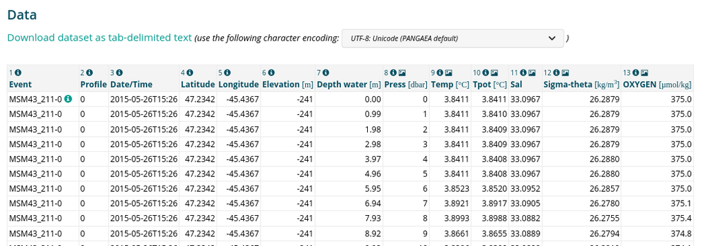

pangaeapy is a python library that loads pangaea datasets into python as tables. Our thin wrapper around it standadizes and builds metadata-aware datasets in xarray, makes certain operations easier (e.g., plotting) and also hosts a collection of standard paths.

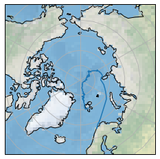

```python
from expeditions import mosaic_paths, arctic_path_S1, pangaea_path_dataset, curated_xrdataset
mosaic_paths.all_legs.path.plot_map()
```

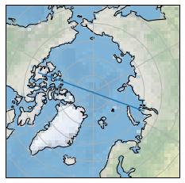

```python
arctic_path_S1.path.plot_map()
```

```python
pangaea_path_dataset("https://doi.pangaea.de/10.1594/PANGAEA.894189")
```

```
<xarray.Dataset>
Dimensions:  (time: 38)
Coordinates:
  * time     (time) datetime64[ns] 2017-07-25T22:18:00 ... 2017-08-14T23:11:00
Data variables:
    lat      (time) float64 78.6 78.61 79.06 79.07 ... 79.03 79.0 78.98 79.03
    lon      (time) float64 5.025 5.055 4.181 4.168 ... 7.002 8.364 9.508 11.1
Attributes:
    Citation:  von Appen, Wilken-Jon; Rohardt, Gerd (2018): Physical oceanogr...
```

# Component: CMIP6 data accessor

**CMIP6 data comes in different "*shapes, sizes and colors*"**

**Raw seaice concentration data examples:**

```
MRI-ESM2-0: siconc [time, y, x]
CESM2: siconc [time, nj, ni]
BCC-ESM1: siconc [time, lat, lon]
AWI-ESM-1-1-LR: siconc [time, ncells]
```

**ESMValTools processed thetao monthly climatology examples:**

```
NorESM2-MM: thetao [month_number, rho, j, i]
CESM2: thetao [month_number, lev, nlat, nlon]
MRI-ESM2-0: thetao [month_number, lev, dim2, dim3]
IPSL-CM6A-LR: thetao [month_number, olevel, dim2, dim3]
```

Example: say to plot crossection along a longitude

```
model1: plot(x='lon', y='lev')
model2: plot(x='longitude', y='depth') ... and so on
```

# Component: CMIP6 data accessor

**CMIP6 data comes in different "*shapes, sizes and colors*"**

We want to address these aspects in our library component, model_data, to make dealing with these datasets easier.

### Aspects:

- **Homoginize data**: rename, reorganize data so that all datasets can be addressed in a similar way.
- **Selection**: select data along paths, and regions.
- **Interpolation (regridding)**: interpolate data to a target grid so that we can compute sums and differences.
- **Address data as collections**: group data into collections and simplify processing further.

# CMIP6 Accessor: Homoginizing datasets

We want to homoginize data (rename, restructure) on the fly so that we can operate on them similarly.

```python
import xarray as xr
sample_dataset = xr.open_dataset('/home/suvarchal/AWI/AO_apps/data_ori/thetao_Omon_IPSL-CM6A-LR_historical_gn_mean_1979_2005.nc')
```

```python
sample_dataset.data_vars, sample_dataset.coords
```

```
(Data variables:
     time_bnds     (time, bnds) datetime64[ns] ...
     nav_lon_bnds  (y, x, nvertex) float32 ...
     nav_lat_bnds  (y, x, nvertex) float32 ...
     olevel_bnds   (olevel, bnds) float32 ...
     area          (y, x) float32 ...
     thetao        (time, olevel, y, x) float32 ...,
 Coordinates:
   * time     (time) datetime64[ns] 1992-07-01T06:00:00
     nav_lon  (y, x) float32 ...
     nav_lat  (y, x) float32 ...
   * olevel   (olevel) float32 0.50576 1.5558553 ... 5698.0605 5902.0576)
```

```python
import model_data
sample_dataset.cmip6.dataset.data_vars, sample_dataset.cmip6.dataset.coords
```

```
(Data variables:
     area     (y, x) float32 ...
     thetao   (time, lev, y, x) float32 ...,
 Coordinates:
   * time          (time) datetime64[ns] 1992-07-01T06:00:00
     time_bnds     (time, bnds) datetime64[ns] ...
     lon           (y, x) float32 ...
     nav_lon_bnds  (y, x, nvertex) float32 ...
     lat           (y, x) float32 ...
     nav_lat_bnds  (y, x, nvertex) float32 ...
   * lev           (lev) float32 0.50576 1.5558553 ... 5698.0605 5902.0576
     olevel_bnds   (lev, bnds) float32 ...)
```

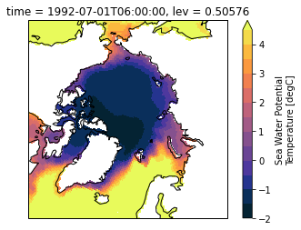

```python
selected_lev = sample_dataset.thetao.cmip6.isel(lev=0) # select using common name "lev" on any dataset containing levels

plot = selected_lev.cmip6.plot_map(projection=ccrs.NorthPolarStereo(), levels=np.arange(-2,5,0.5), cmap="cmo.thermal")  # plot on projection

plot.axes.set_extent((-180,180, 60, 90), crs=ccrs.PlateCarree()) # set extents of plot
_ = plot.axes.coastlines() # draw coastlines
```

# CMIP6 Accessor: Selection

We want to select points in model representative of path along expedition. For demonstration a point (lon, lat) in path.

- For rectilinear grids, nearest neighbor selection is closest lat, then lon or vice versa.
- For Curvilinear or unstructured grids, each dimention is function of lat,lon. Distance to grids points can be the metric.
  - project, build tree, query tree

```python
from expeditions import  arctic_path_S1, mosaic_paths
```

```python
sample_dataset = xr.open_dataset("/home/suvarchal/AWI/AO_apps/data_ori/thetao_Omon_AWI-CM-1-1-MR_historical_r1i1p1f1_gn_mean_1979_2005.nc")
sample_dataset.cmip6.sel(path=arctic_path_S1)
```

```
<xarray.Dataset>
Dimensions:  (lev: 46, ncells: 40, time: 1)
Coordinates:
  * time     (time) datetime64[ns] 1992-07-01T06:00:00
  * lev      (lev) float64 -0.0 10.0 20.0 30.0 ... 5.4e+03 5.65e+03 5.9e+03
  * ncells   (ncells) float64 0.0 111.6 223.1 ... 4.131e+03 4.243e+03 4.354e+03
Data variables:
    thetao   (time, lev, ncells) float32 ...
```

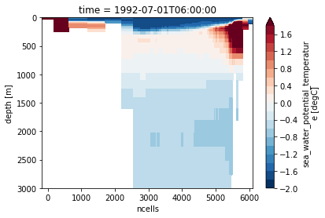

```python
plot = sample_dataset.cmip6.sel(path=mosaic_all_legs).thetao.plot(x='ncells', y='lev', ylim=(3000,0), levels=np.arange(-2,2,0.2), cmap="RdBu_r")
```

We can also select by regions, or group of regions.

```python
import regionmask
arctic_ocean = regionmask.defined_regions.natural_earth.ocean_basins_50.polygons[0]
```

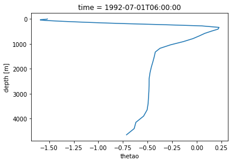

```python
sample_dataset_ao = sample_dataset.cmip6.sel(region=arctic_ocean) # select all points in AO
plot = sample_dataset_ao.mean(dim='ncells').thetao.plot(y='lev', yincrease=False) # plot mean thetao profile
```

# CMIP6 Accessor: Interpolation

**Selection on nearest neighbor might not be best representative (e.g., close to land)**

```python
sample_dataset = xr.open_dataset('/home/suvarchal/AWI/AO_apps/data_ori/thetao_Omon_IPSL-CM6A-LR_historical_gn_mean_1979_2005.nc')
nn_selection = sample_dataset.cmip6.sel(path=mosaic_all_legs)
nn_selection_tol = sample_dataset.cmip6.sel(path=mosaic_all_legs, tolerance=100000)
wa_selection_tol = sample_dataset.cmip6.sel(path=mosaic_all_legs, tolerance=100000, method='inverse_weighted')
```

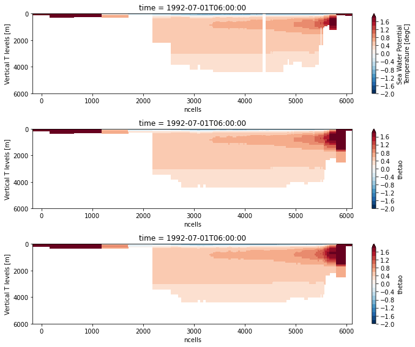

```python
fig, axs = plt.subplots(3)
fig.set_size_inches(10,8)
nn_selection.thetao.plot(x='ncells', yincrease=False, levels=np.arange(-2,2,0.2), ax=axs[0])
nn_selection_tol.thetao.plot(x='ncells', yincrease=False, levels=np.arange(-2,2,0.2), ax=axs[1])
wa_selection_tol.thetao.plot(x='ncells', yincrease=False, levels=np.arange(-2,2,0.2), ax=axs[2])
plt.tight_layout()
```

- when tolerance is specified, we can also compute stderr, additionally check for significane if needed.
- regridding of model data to a ref grid (obs). if we want to compute differences.

# CMIP6 Accessor: Collection of datasets

A CMIP6 data collection (this software wise) is collection of models that represent variables from a same experiment.

```python
from model_data import CMIP6DatasetCollection
hist_clim_collection = CMIP6DatasetCollection.from_path("/home/suvarchal/AWI/AO_apps/data_ori/",
                                                        ignore_files=["thetao_Omon_PHC_historical_gn_mean_1979_2005_nan.nc"])
                                                       # climatology data prepared by Nargis
```

```python
hist_clim_collection
```

```
Models: ['SAM0-UNICON', 'GISS-E2-1-H', 'MIROC6', 'IPSL-CM6A-LR', 'AWI-CM-1-1-MR', 'EC-Earth3-Veg', 'EC-Earth3', 'NESM3', 'BCC-CSM2-MR', 'CESM2-WACCM', 'CESM2', 'CanESM5']
```

```python
selected = hist_clim_collection.sel(path=arctic_path_S1)
selected
```

```
Models: ['SAM0-UNICON', 'GISS-E2-1-H', 'MIROC6', 'IPSL-CM6A-LR', 'AWI-CM-1-1-MR', 'EC-Earth3-Veg', 'EC-Earth3', 'NESM3', 'BCC-CSM2-MR', 'CESM2-WACCM', 'CESM2', 'CanESM5']
```

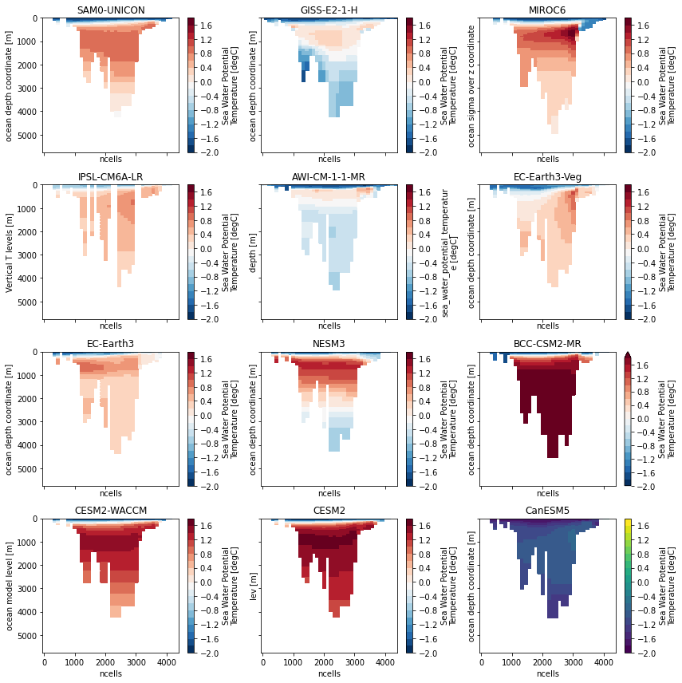

```python
fig, axs = plt.subplots(4,3, sharex=True, sharey=True)
fig.set_size_inches(12,12)
_ = selected.plot(var="thetao", axs=axs, yincrease=False, levels=np.arange(-2,2,0.2))
plt.tight_layout()
```

**TODOs**:

- collection.mean() for multimodel mean.
- collection - obs, automatically interpolating to obs.
- plotting maps etc.

# Component: FESOM

To increase uptake of FESOM:

- Lack of full support for unstructured grids in standard libraries means we have to provide ways for common operations: pyfesom2.
- pyfesom2 should have data batteries included.

```python
import pyfesom2
pyfesom2.datasets
```

```
['lcore', 'a01']
```

```python
lcore_data = pyfesom2.datasets.lcore # remote data from dkrz cloud
lcore_data
```

```
<xarray.Dataset>
Dimensions:  (nod2: 126858, nz1: 47, time: 144)
Coordinates:
    lat      (nod2) float64 dask.array<chunksize=(126858,), meta=np.ndarray>
    lon      (nod2) float64 dask.array<chunksize=(126858,), meta=np.ndarray>
  * nz1      (nz1) float64 -2.5 -7.5 -15.0 ... -5.525e+03 -5.825e+03 -6.125e+03
  * time     (time) datetime64[ns] 1948-01-31T23:15:00 ... 1959-12-31T23:15:00
Dimensions without coordinates: nod2
Data variables:
    temp     (time, nod2, nz1) float32 dask.array<chunksize=(1, 126858, 47), meta=np.ndarray>
```

```python
#lcore_data.pyfesom2.sel(path)
```

# Next Months ...

- **Lot of todos, regridding, plotting, etc.**
- **Stablize the API, more tests.**
- **Make good examples for users (documentation).**

*Feedback, datasets and participation is warmly welcomed.*